# How to use the tcG package

## Introduction

This package contains all the functions needed to fit the models presented in Boutigny et al. (2023)[^1].

The main functions of the package are `tcG.fit`, `extGP.fit` that are used to fit the models and `res.plot` can be used to draw plots. You can check the documentation pages.

```r
# install: change the character with the path to your zip file
# devtools::install("path/tcG-main")

# load
library(tcG)
```

```r
?tcG.fit
?extGP.fit
?res.plot
```

Two types of models can be fitted with this package, all aiming at modeling precipitation which we will note $Y$.

### Meta-Gaussian models

A meta-Gaussian model can be written as

$$Y = 0*\mathbb{I}_{X<0} + \psi(X)*\mathbb{I}_{X\geq0} \text{, with } X\sim \mathcal{N}(\mu,1)$$
where $\mathbb{I}$ is the indicator function equals to 1 if the condition is true and 0 else. $\mu$ is the parameter that controls the probability of dry measurement. The transformation $\psi$ is called the anamorphosis, and 4 options are available in the package:

- `gp` (for Generalized Pareto): $\psi(x) = y_m+\sigma x^{\frac{1}{\alpha}}\exp{\frac{\xi x^2}{2}}$
- `power`: $\psi(x) = y_m+\sigma x^{\frac{1}{\alpha}}$
- `quadratic-power`: $\psi(x) = y_m+\sigma_1 x^{\frac{1}{\alpha}}+\sigma_2 x^{\frac{2}{\alpha}}$
- `power-exp`: $\psi(x) = \sigma_2 (\exp(\sigma_1x^{1/\alpha})-1)$

$y_m$ is the minimal value that can be observed.

The choice of the anamorphosis will always be controlled by the argument `name`.

### Extended Generalized Pareto model

This model is the one of [Naveau et al. (2016)](https://agupubs.onlinelibrary.wiley.com/doi/pdfdirect/10.1002/2015WR018552)[^2]. It models only the positive part of the distribution and can be written as

$$Y_+ = y_m + \sigma H^{-1}_\xi(U^{1/\alpha})$$
where $U \sim Unif(0,1)$, $H_\xi$ is the cdf of a GPD and $y_m$ is the minimal value that can be observed.

## Data

Load the package and the provided data set.

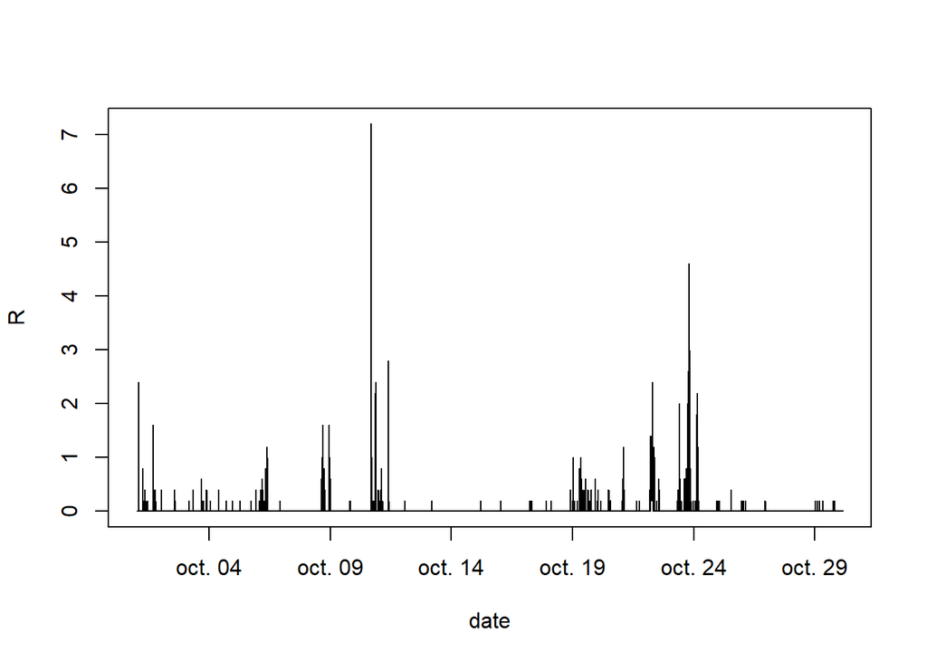

```r
data(guip)

# using only October to avoid long calculations
guip=guip[lubridate::month(guip$date)==10,]

plot(guip[1:7000,], type="l")
```

## Fitting meta-Gaussian models

### First fit

As a first example the `gp` transformation will be fitted. The argument `name` is a vector containing the names of the transformations that I want to fit. `init` is a list, named according to those transformations, which contains initial values for the parameters:

```r
init=list("power"=c(mu, sigma, alpha),
          "gp"=c(mu, sigma, alpha, xi),
          "power-exp"=c(mu, sigma1, sigma2, alpha),
          "quadratic-power"=c(mu, sigma1, sigma2, alpha))
```

$y_m$ is the minimal value that can be observed and $step$ is the precision of the data. Finally `R` and `bootstrap` control the bootstrap replicates.

```r
sort(unique(guip$R))
```

```
#>  [1] 0.0 0.2 0.3 0.4 0.5 0.6 0.7 0.8 0.9 1.0 1.1 1.2 1.3 1.4 1.5 1.6 1.7 1.8 1.9
#> [20] 2.0 2.1 2.2 2.3 2.4 2.5 2.6 2.7 2.8 2.9 3.0 3.1 3.2 3.3 3.5 3.9 4.0 4.1 4.6
#> [39] 4.7 4.8 5.2 7.2 7.8 9.4
```

```r
res=tcG.fit(guip$R, name="gp", init=list("gp"=c(-1,0.5,0.5,0.5)), ym=0.2, step=0.2, R=50)
```

```
#> [1] "gp"
```

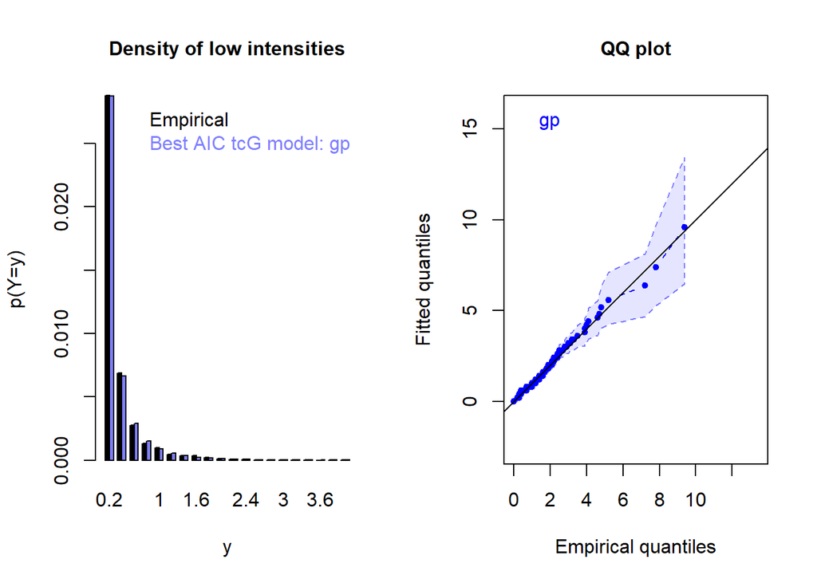

```r
# fitted parameters
res$par
```

```
#> $gp
#> [1] -1.7207684  0.5829441  0.6563083  0.4389557
```

The default results include a plot for low intensities with a barplot zoomed on the 20 first steps, and a quantile-quantile plot that gives a better view of the global fit. The light area on the qqplot give the 95% interval computed with the bootstrap replicates.

### The impact of discretization

Taking into account the discretization of precipitation is especially important at fine time scales. In the package there are two options to fit the models: the continuous likelihood and the discrete one. Choosing one is made by inquiring the precision of the data. If `step==0` (default) the continuous likelihood is used, else it is the discrete one.

```r
sort(unique(guip$R))
```

```
#>  [1] 0.0 0.2 0.3 0.4 0.5 0.6 0.7 0.8 0.9 1.0 1.1 1.2 1.3 1.4 1.5 1.6 1.7 1.8 1.9
#> [20] 2.0 2.1 2.2 2.3 2.4 2.5 2.6 2.7 2.8 2.9 3.0 3.1 3.2 3.3 3.5 3.9 4.0 4.1 4.6
#> [39] 4.7 4.8 5.2 7.2 7.8 9.4
```

```r
res_cont=tcG.fit(guip$R, name="gp", init=list("gp"=c(-1,0.5,0.5,0.5)), ym=0, step=0, R=50)
```

```
#> [1] "gp"
```

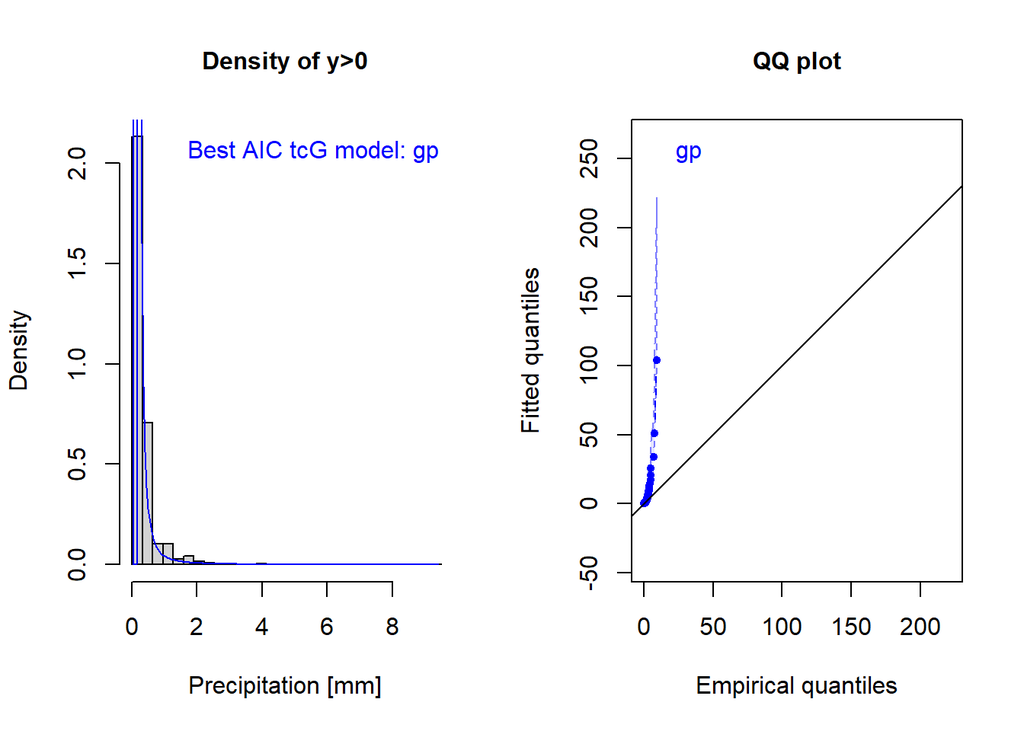

```r
res_dis=tcG.fit(guip$R, name="gp", init=list("gp"=c(-1,0.5,0.5,0.5)), ym=0.2, step=0.2, R=50)
```

```
#> [1] "gp"
```

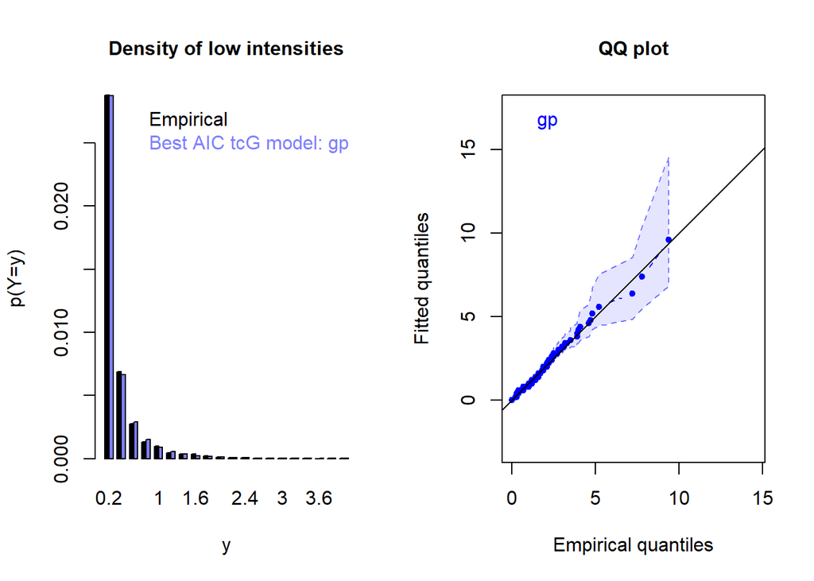

### Comparing several meta-Gaussian models

```r
res=tcG.fit(guip$R, name=c("power", "gp"),
            init=list("power"=c(-1,1,2), "gp"=c(-1,.5,0.5,0.5)),
            ym=.2, step=.2, R=50)
```

```
#> [1] "power"
#> [1] "gp"
```

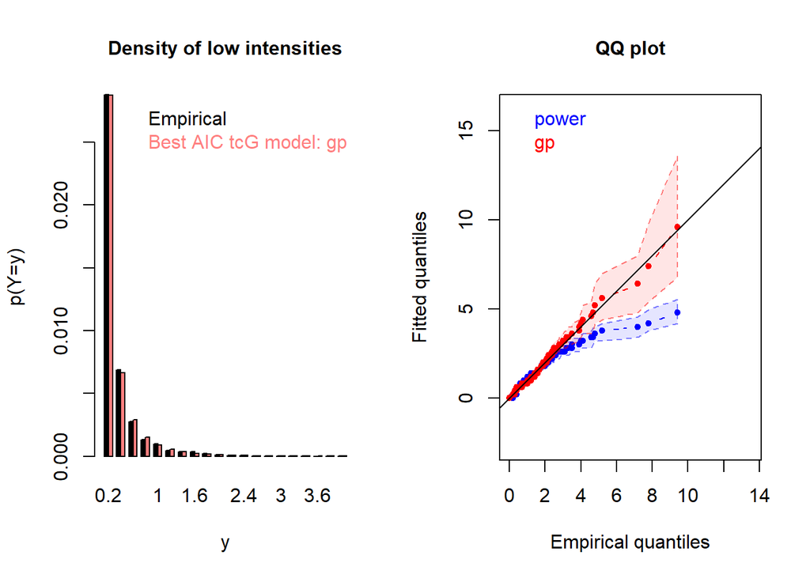

```r
# parameters
res$par
```

```
#> $power
#> [1] -1.720982  0.794918  1.930151
#>
#> $gp
#> [1] -1.7207684  0.5829441  0.6563083  0.4389557
```

```r
# AIC
which.min(res$AIC)
```

```
#> gp
#>  2
```

## Fitting the extended GP model

```r
# uniquement sur les mesures positives
res=extGP.fit(guip$R[guip$R>0], init=c(.5,.5,.5), ym=0.2, step=0.2, R=50)
```

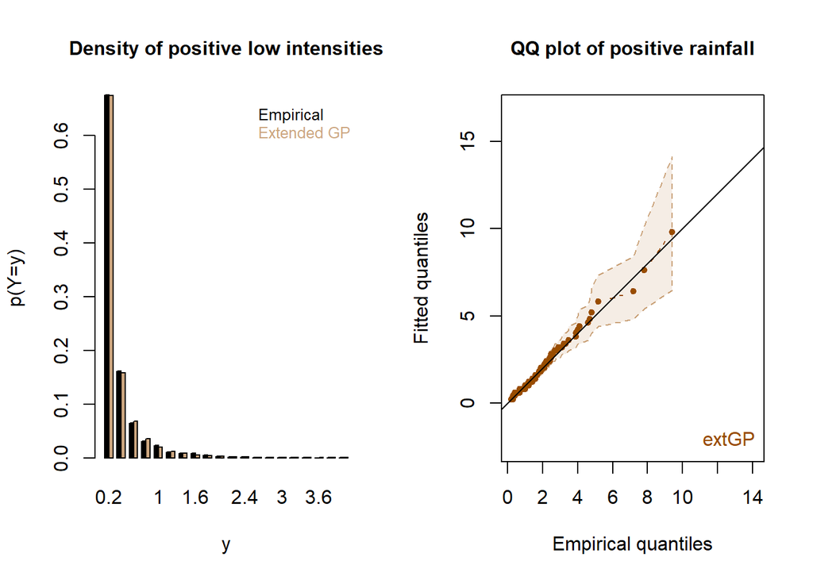

```r
res$par
```

```
#> [1] 0.2205567 0.6481637 0.3630870
```

## Comparing meta-Gaussian and extended GP

We’re not going to use the default plots, but the `res.plot` function.

```r
res_tcG=tcG.fit(guip$R, name="gp", init=list("gp"=c(-1,.5,0.5,0.5)), ym=0.2, step=0.2, R=50, plots=FALSE)
```

```
#> [1] "gp"
```

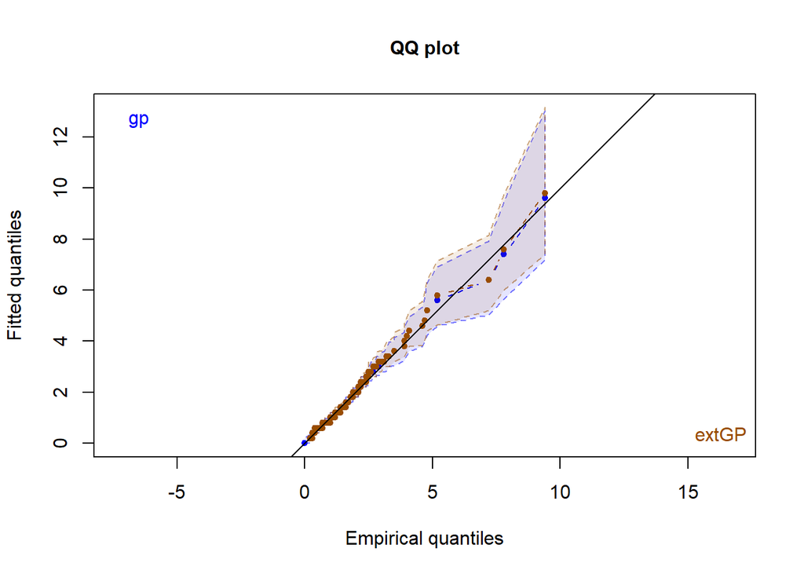

```r
res_eGP=extGP.fit(guip$R[guip$R>0], init=c(.5,0.5,0.5), ym=0.2, step=0.2, R=50, plots=FALSE)

# plot
res.plot(res.tcG=res_tcG, res.extGP=res_eGP, y=guip$R, ym=0.2, step=0.2, choice="qqplot")
```

[^1]: Boutigny, M., Ailliot, P., Chaubet, A., Naveau, P., & Saussol, B. (2023). A meta-Gaussian distribution for sub-hourly rainfall. Stochastic Environmental Research and Risk Assessment, 1-13.
[^2]: Naveau P, Huser R, Ribereau P, Hannart A (2016). “Modeling jointly low, moderate, and heavy rainfall intensities without a threshold selection.” *Water Resources Research*, **52**(4), 2753–2769.